# A Tutorial on Principal Component Analysis · Michael J. Flynn's blog

[figure not shown]

### Michael J. Flynn

Welcome to my blog!

[GitHub](https://github.com/YourUsername)  
[Twitter](https://twitter.com/Michaeljaflynn)  
Email

# [A Tutorial on Principal Component Analysis](https://michaeljflynn.net/a-tutorial-on-principal-component-analysis.html)

**Note: imported from an earlier version of this blog.**

## Introduction

Machine learning is a buzzword these days. Just dropping it can impress people without requiring that you elaborate, perhaps because it feeds their fantasies of a robot takeover. Investors are particularly vulnerable because they get to act on these fantasies. The following exchange approximates one that actually happened in real life:

“We’ve got a couple cutting edge projects coming down the pipeline: cloud computing and *machine learning*!”

“Wow! I’m terribly excited about all this! Hail our new overlords! Take my money!”

Notice that money changed hands without inquiry into what these two concepts were being used for.

All this means is that, whoever you are, it is especially important to become familiar with the real tools of machine learning and data science, what problems they are meant to solve, and how they solve them.

This is a tutorial on “principal component analysis”, or PCA, a technique used to reduce *redundancy* in your data. In any given dataset, you might have two or more measurements that actually measure the same thing. One example would be a dataset measuring students’ hours spent doing schoolwork and their GPA. These 2 variables could be interpreted as measuring 1 underlying quality of a student: how much of a “good student” they are. We might want to reduce these 2 factors into this “good student” measure because this greatly simplifies statistical analysis. That’s where PCA comes in. PCA rotates your data’s coordinate system to one that aligns with the important questions i.e. whether a student is a good student or not (GPA + hours worked), or how naturally smart or efficient they are (GPA – hours worked). It also gives a score on how important these factor are.

In this tutorial I am going to set up a situation where there is one underlying phenomenon: the motion of a spring in one direction. I’m going to duplicate and obfuscate this phenomenon by having a fictional group of scientist measure this it with several different cameras. Then I’m going to use PCA to isolate the signal.

## Setting up redundant data

Let’s say we have a ball attached to a spring. The balls motion might be described as
$$x(t) = cos(t)$$
around the equilibrium point. I can model this in R.

```
library(ggplot2)
library(tidyr)
library(dplyr)
theme_set(theme_bw()) # set default theme to black-white
t <- seq(0, 6*pi, by = .1)
x <- cos(t)
qplot(x = t, y = x)
```

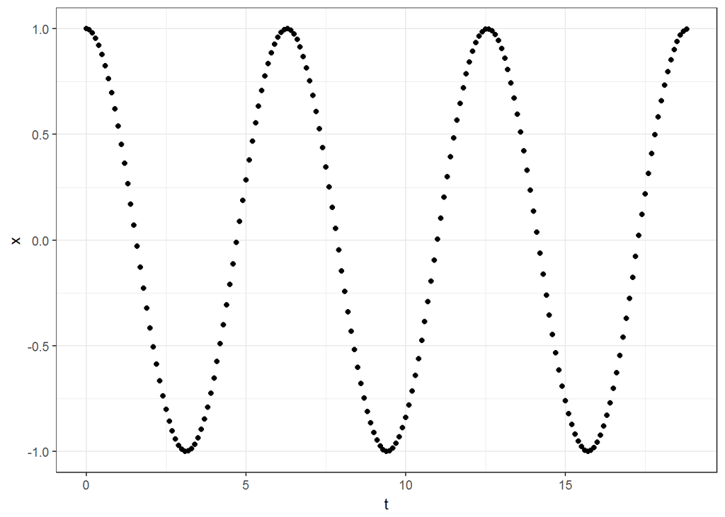

The above plot is how the position $x$ varies with time. Of course, in the real world the ball has 3 spatial coordinates and every measurement has noise. To account for these I’m going to add $y$ and $z$ coordinates, which are both 0 and I’m also going to add noise in every direction.

```
positions <- data.frame(t = seq(0, 6*pi, by = .1),
                        x = x + rnorm(length(x), sd = .1),
                        y = rnorm(length(x), sd = .1),
                        z = rnorm(length(x), sd = .1))

ggplot(data = gather(positions, variable, value, x:z), aes(x = t, y = value)) +
    geom_point() +
    facet_wrap(~ variable, nrow = 1)
```

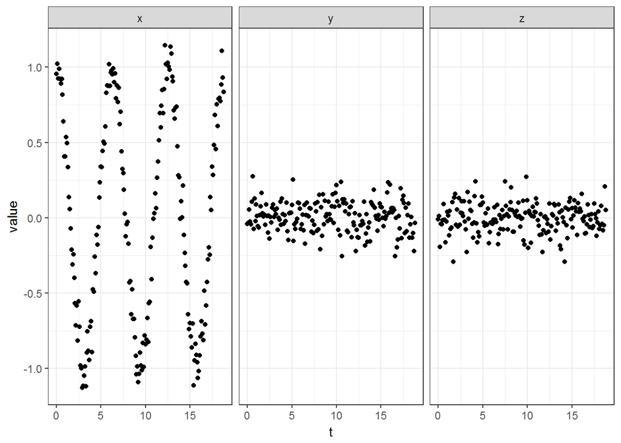

Now you can see 3 relationships, one of mostly signal, 2 of noise.

Now let’s say a team of scientists have set up 3 cameras to observe this process. They do not have priviledged access to the coordinate system that we know of, where the $x$ coordinate contains all the signal. Rather, for each camera they get two coordinates: the $x$ and $y$ of the ball’s location in the camera’s image plane. For simplicity’s sake, I’m going to assume each camera is pointed directly at the midpoint of the ball’s motion. I’m going to assert, and you can prove to yourself, that a camera’s image plane coordinates can be expressed by rotating and scaling the original coordinate system, and then projecting the data onto two of the resulting dimensions.

One side note: In the process of writing this post, I discovered that generating a random 3D-rotation is actually super annoying. I spent a little bit of time trying to tie the concept down and this is what I’ve come up with: a rotation can be uniquely specified by an axis and an angle to rotate around that axis. You can read about all that [here](http://math.stackexchange.com/questions/442418/random-generation-of-rotation-matrices) and [here](https://en.wikipedia.org/wiki/Rotation_matrix#Conversion_from_and_to_axis-angle), or you can just steal my code.

```
## random 3d rotation matrix
random.rotation.matrix <- function(seed) {
 set.seed(seed)

 ## angle around vector to rotate
 psi <- runif(1, max = 2*pi)

 ## select a random point on S^2
 phi <- runif(1, max = 2*pi)
 theta <- acos(2 * runif(1) - 1)

 ## construct axis from random S^2 point
 axis <- c(cos(theta)*cos(phi),
          cos(theta)*sin(phi),
          sin(theta))

 ## cross product matrix for formula
 axis.cp <- matrix(c(0, -axis[3], axis[2],
                     axis[3], 0, -axis[1],
                     -axis[2], axis[1], 0), nrow = 3, byrow = TRUE)

 ## create rotation matrix using wikipedia formula
 R <- cos(psi) * diag(c(1,1,1)) +
      sin(psi) * axis.cp +
      (1-cos(psi)) * outer(axis, axis)

 R
}
```

I’ve tested the above function and it does seem to create random rotations. So let’s go ahead an find the new coordinates!

```
new.camera.data <- function(positions, seed) {
 set.seed(seed)
 ## original data
 original.coordinates <- t(as.matrix(select(positions, x,y,z)))

 ## get scale
 scale <- 1/rexp(1, 1/3)

 ## get rotation
 rotation <- random.rotation.matrix(seed)

 ## new points
 new.points <- t(scale * rotation %*% original.coordinates)

 ## project
 image.plane.projection <- new.points[,1:2]

 list(scale = scale, rotation = rotation, data = image.plane.projection)
}

camera.1 <- new.camera.data(positions, 1)
camera.2 <- new.camera.data(positions, 2)
camera.3 <- new.camera.data(positions, 3)

camera.data = data.frame(t = seq(0, 6*pi, by = .1),
                         x1 = camera.1$data[,1],
                         y1 = camera.1$data[,2],
                         x2 = camera.2$data[,1],
                         y2 = camera.2$data[,2],
                         x3 = camera.3$data[,1],
                         y3 = camera.3$data[,2])

ggplot(data = gather(camera.data, variable, value, x1:y3), aes(x = t, y = value)) +
    geom_point() +
    facet_wrap(~ variable, nrow = 2)
```

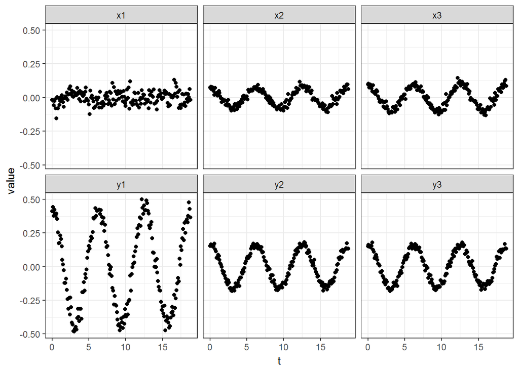

It now looks that there are several signals here, but the scientists are suspicious because they seem very correlated. How will they isolate the signal?

## Finding the Principal Components

PCA is based on the hypothesis that signals are things that cause your data to vary. Therefore, directions that possess large signals will also have data that varies in that direction. This leads us to the fundamental assumption of PCA:

**Fundamental Assumption of PCA:** The most important directions are the directions in which the data *varies most*.

Note that this implicitly assumes that the signal to noise ratio,
$$\frac{\sigma_{signal}^2}{\sigma_{noise}^2}> 1.$$
Only then will the signal directions be expected to be the directions of greatest variation. It many real-world applications, for example stock price forecasting, the noise overwhelms the signal. It would be an interesting exercise to see how this simple example breaks down as you add noise.

Thus, PCA becomes an optimization problem. Let the matrix of data with each column translated so that it is mean 0 ($a \to a–mean(a)$) be denoted $\mathbf X$. You will soon see why this translation is important. Since translation does not effect variance, we are trying to find some unit vector $\mathbf u$ such that the variance of $\mathbf X \mathbf u$ is maximized.

$$\text{Maximize Var(}{\mathbf X \mathbf u} \text{)}
\quad \text{ subject to } \quad ||\mathbf u|| = 1,$$

repeatedly such that each $\mathbf u_i \cdot\mathbf u_j = 0$ for $i \neq j$ until our directions span the space of the data.

To solve this, let’s talk about variance for a bit. Consider two sets of measurements
$$\mathbf a = \{ a_1, a_2,…, a_n\}
\quad \text{ and
} \quad \mathbf b = \{b_1, b_2,…,b_n\}$$
with means of $\mu_a$ and $\mu_b$, respectively. The variance and covariance are defined as average squared differences from the mean:
$$\text{Var}(\mathbf a) =
\sigma_{\mathbf a}^2 = \frac{1}{n} \sum_i(a_i – \mu_a)^2 =
\frac{1}{n}
\sum_i a_i^2 = \frac{1}{n} \mathbf a \cdot \mathbf a \quad \text{if
}
\mu_a = 0,$$
$$\text{Cov}(\mathbf a, \mathbf
b) =
\sigma_{\mathbf{ab}}^2 = \frac{1}{n} \sum_i(a_i – \mu_a)(b_i –
\mu_b)
= \frac{1}{n} \sum_i a_ib_i = \frac{1}{n}\mathbf a \cdot \mathbf b
\quad \text{if } \mu_a =0 \text{ and } \mu_b = 0.$$

So the variance is equal to the covariance of a variable with itself,
$$\text{Var}(\mathbf{a}) = \text{Cov}(\mathbf a,
\mathbf a).$$
Since all of $\mathbf X$’s columns $\mathbf x_i$, are mean zero, we can define a matrix $\mathbf C$ where the $(i,j)\text{th}$ member is the covariance of $\mathbf x_i$ and $\mathbf x_j$.

$$\frac{1}{n} \mathbf X^T \mathbf X =
\begin{bmatrix}
\frac{1}{n} \mathbf x_1 \cdot \mathbf x_1 & \cdots & \frac{1}{n}
\mathbf x_1 \cdot \mathbf x_r \\
\vdots & \ddots & \vdots \\
\frac{1}{n} \mathbf x_r \cdot \mathbf x_1 & \cdots & \frac{1}{n}
\mathbf x_r \cdot \mathbf x_r \end{bmatrix} = \mathbf C.$$

Let’s do this now with our camera measurments in R.

```
options(width = 120)
measurements <- select(camera.data, -t)
measurements <- mutate_each(measurements, funs(. - mean(.)))
measurements <- as.matrix(measurements)
covariance.matrix <- t(measurements) %*% measurements / nrow(measurements)

covariance.matrix
```

```
##               x1           y1            x2           y2            x3           y3
## x1  0.0021234862 -0.005043854 -0.0002620748 -0.002255248 -0.0005278387 -0.002325504
## y1 -0.0050438535  0.092671234  0.0166668085  0.034679534  0.0217014469  0.034022588
## x2 -0.0002620748  0.016666808  0.0032414307  0.006126479  0.0041287510  0.005953620
## y2 -0.0022552479  0.034679534  0.0061264792  0.013067542  0.0079891875  0.012826169
## x3 -0.0005278387  0.021701447  0.0041287510  0.007989187  0.0053130622  0.007799908
## y3 -0.0023255041  0.034022588  0.0059536201  0.012826169  0.0077999083  0.012612169
```

Let’s also reframe our optimization problem in terms of this nice, square, symmetric matrix:

$$\text{Var}(\mathbf{X} \mathbf u) =
\frac{1}{n}(\mathbf{X} \mathbf u)^T (\mathbf{X} \mathbf u) = \mathbf u^T
(\frac{1}{n} \mathbf{X}^T \mathbf{X}) \mathbf u = \mathbf u^T \mathbf{C}
\mathbf u.$$

Therefore we are trying find a $\mathbf u$ that maximizes the matrix product with the covariance matrix, $\mathbf u^T \mathbf C \mathbf u$ such that $\mathbf u$ is a unit vector and perpendicular to the other solutions we have found. Remember that $\mathbf C$ is a square, symmetric matrix, and its set of unit eigenvectors $\{\mathbf v_1, \mathbf v_2,\dots, \mathbf v_r\}$ are orthogonal, i.e. $\mathbf v_i \cdot \mathbf v_j = 0$ for $i \neq j$, and span it’s column and row spaces. Therefore we can express $\mathbf u$ as some combination of the orthogonal unit eigenvectors of $\mathbf C$:

$$\mathbf u = a_1 \mathbf v_1 + a_2 \mathbf v_2 +
\dots + a_r \mathbf v_r,$$

where $\sum a_i^2 = 1$ to make the result length 1. What happens when we make this substitution into the quantity we are trying to optimize?

$$\begin{align*} \mathbf u^T \mathbf C \mathbf u &=
(a_1 \mathbf v_1^T + a_2 \mathbf v_2^T + \dots + a_r \mathbf
v_r^T) \mathbf C
(a_1 \mathbf v_1 + a_2 \mathbf v_2 + \dots + a_r \mathbf v_r) \\
&= (a_1 \mathbf v_1^T + a_2 \mathbf v_2^T + \dots + a_r \mathbf
v_r^T)
(a_1 \mathbf C \mathbf v_1 + a_2 \mathbf C \mathbf v_2 + \dots +
a_r \mathbf C \mathbf v_r) \\
&= (a_1 \mathbf v_1^T + a_2 \mathbf v_2^T + \dots + a_r \mathbf
v_r^T)
(a_1 \lambda_1 \mathbf v_1 + a_2 \lambda_2 \mathbf v_2 + \dots +
a_r \lambda_r \mathbf v_r) \\
&= a_1^2 \lambda_1 + a_2^2 \lambda_2 + \dots + a_r^2 \lambda_r
\quad \text{because the } \mathbf v \text{‘s are
orthogonal.}\end{align*}$$

This is very interesting. Let
$$\{\alpha_1,
\alpha_2, …, \alpha_r \} = \{a_1^2, a_2^2, …, a_r^2\},$$
we are trying to solve an optimization of the form
$$\begin{align*}
\text{Maximize} \quad \alpha_1 \lambda_1 + &\alpha_2 \lambda_2 +
\dots + \alpha_r \lambda_r \\
\text{Subject to} \quad \sum_i \alpha_i &= 1 \\
\text{All } \alpha_i & \geq 0
\end{align*}$$

This is a linear programming problem, where all solutions will be on the *corners* of the space. On the corners, the inequalities are tight, so the solutions are where $r-1$ $\alpha$’s are 0, and exactly one $\alpha_i = 1$, so $a_i = \sqrt{\alpha_i} = 1$.

So $\mathbf u_i = \mathbf v_i$, where the $i\text{th}$ most important direction has the $i\text{th}$ largest eigenvalue. The solutions are the eigenvectors of the covariance matrix. Since the eigenvalues are orthogonal, our coordinate system is orthogonal. Pretty cool result, if you ask me.

## Isolating the signal

Some people use the singular SVD to get the eigenvectors and eigenvalues. If there is a deeper reason to use SVD, feel free to email me! I am curious. Here, I’m just going to use the R function `eigen` to grab the eigenvectors.

First I’m going to look at the eigenvalues. I expect to see 1 large eigenvalue, and 5 much smaller values. What I’m going to do then is get the eigenvectors, project the data into that basis, and plot the results.

```
important.directions <- eigen(covariance.matrix)
important.directions$value
```

```
## [1]  1.265056e-01  2.491410e-03  3.188713e-05  1.083847e-17  3.857996e-18 -2.696033e-18
```

```
projected <- as.data.frame(measurements %*% important.directions$vector)
colnames(projected) <- paste0("component", 1:6)
projected$t <- camera.data$t

plot.data <- gather(projected, component, value, component1:component6)
ggplot(data = plot.data, aes(x = t, y = value)) + geom_point() +
    facet_wrap(~component)
```

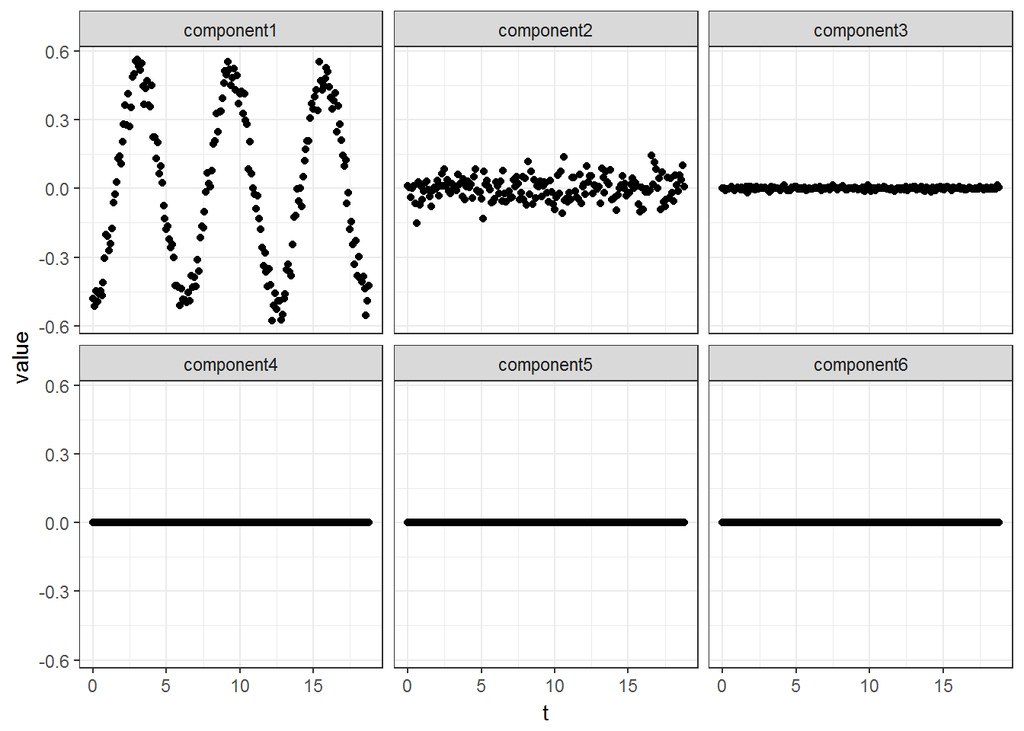

We’ve not only isolated the signal, we’ve also isolated the noise as well! PCA has saved the scientists from the complicated analysis of 6 signals, and given them only one to work with. Problem solved.

## Further reading

[Jonathan Schlen’s Tutorial on PCA](https://arxiv.org/pdf/1404.1100v1.pdf)

[Stack exchange post on PCA](http://stats.stackexchange.com/questions/2691/making-sense-of-principal-component-analysis-eigenvectors-eigenvalues)

#### Published

Mon 06 February 2017

#### Category

[misc](https://michaeljflynn.net/categories.html#misc-ref)

#### Tags

- [Machine Learning 1](https://michaeljflynn.net/tags.html#machine-learning-ref)
- [PCA 1](https://michaeljflynn.net/tags.html#pca-ref)
- [R 1](https://michaeljflynn.net/tags.html#r-ref)